# Relatorio 3 - MAF 261 - Estatística Experimental

Guilherme Fernandes - 3398, Júlia Letícia - 3732, Victor Hugo - 3510

05/07/2022

# Relatório 3

## Introdução

Um grupo de engenheiros agrônomos testaram 4 diferentes tipos de fertilizante em áreas com plantação de feijão e mediram a produção em quilogramas. Ainda, anotaram se houve ataque de pragas ou não.

## Base de Dados

| ID | Producao | Praga | Fertilizante |
| --- | --- | --- | --- |
| 1 | 388 | 1 | A |
| 2 | 454 | 0 | A |
| 3 | 812 | 0 | A |
| 4 | 514 | 1 | A |
| 5 | 526 | 0 | A |
| 6 | 843 | 0 | A |

### Sumário

ID: ID da área plantada;  
Producao: Quantidade da produção em relação a área $i \in ID$;  
Praga: 0 quando não houver presença de praga na área $i \in ID$;  
Fertilizante: Qual tipo de fertilizante utilizado na área $i \in ID$;

## Objetivos

Temos como objetivo descobrir se algum fertilizante é melhor para a produção (1), se algum fertilizante causa menos pragas (2) e se as pragas afetam a produção de cada tipo de fertilizante (3).

## Objetivo 1

### Descritiva da produção em relação aos tipos de Fertilizante

| Fertilizante | Mediana | Média | Mínimo | Máximo | Desvio Padrão | Variância |
| --- | --- | --- | --- | --- | --- | --- |
| A | 520.0 | 589.50 | 388 | 843 | 191.03 | 36492.70 |
| B | 941.5 | 938.33 | 697 | 1195 | 180.86 | 32711.07 |
| C | 251.0 | 250.50 | 55 | 557 | 180.21 | 32475.50 |
| D | 379.5 | 406.00 | 286 | 640 | 131.67 | 17336.40 |

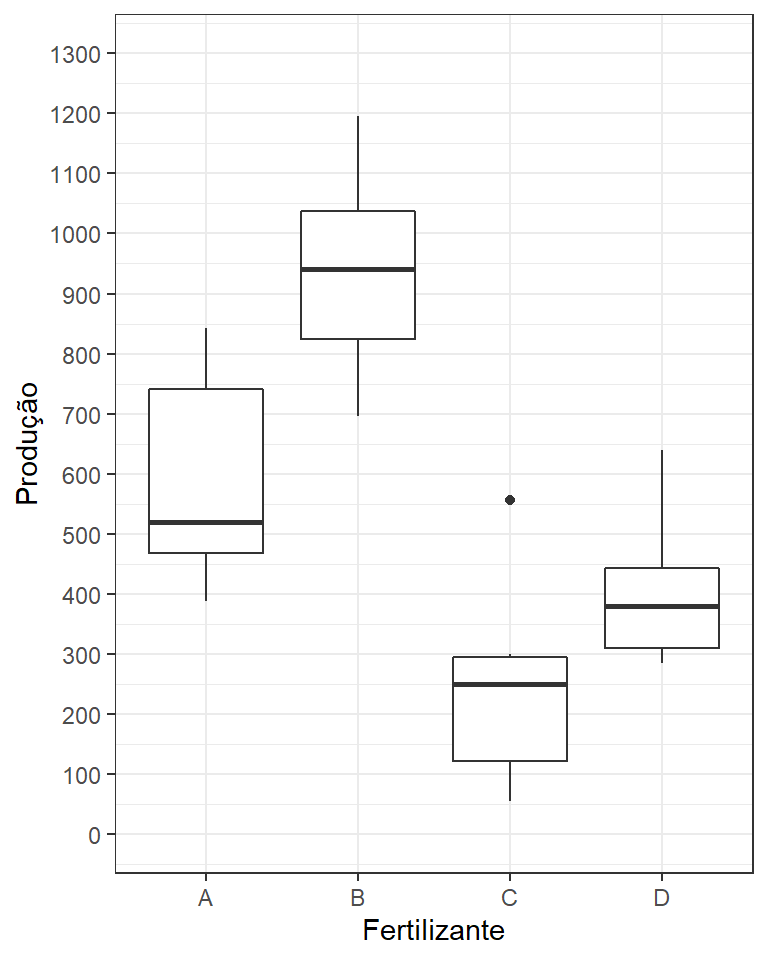

Podemos observar que $B$ visualmente é superior que os outros, agora iremos analisar estatisticamente.

### ANOVA

```
##              Df  Sum Sq Mean Sq F value   Pr(>F)
## Fertilizante  3 1576427  525476   17.66 7.66e-06 ***
## Residuals    20  595078   29754
## ---
## Signif. codes:  0 '***' 0.001 '**' 0.01 '*' 0.05 '.' 0.1 ' ' 1
```

A um nível de significância de 5% foi possível ver que a produção é diferente em relação aos fertilizantes. Dessa forma vamos testar os pressupostos e depois encontrar onde está a diferença.

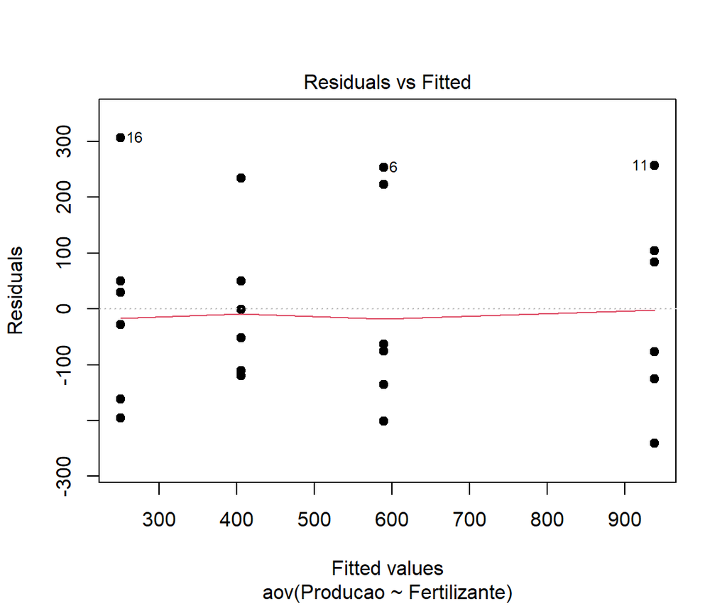

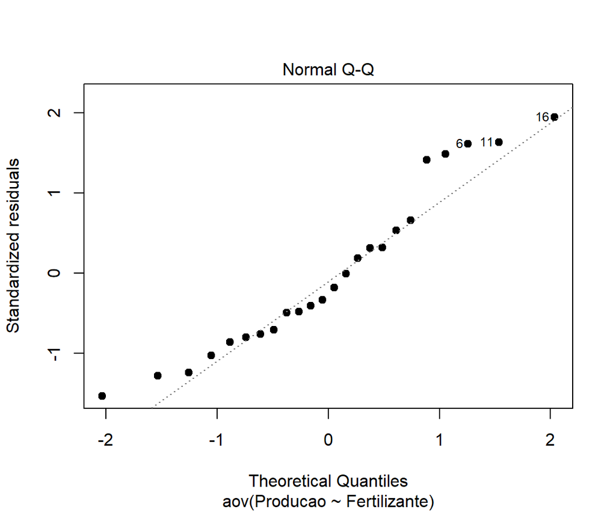

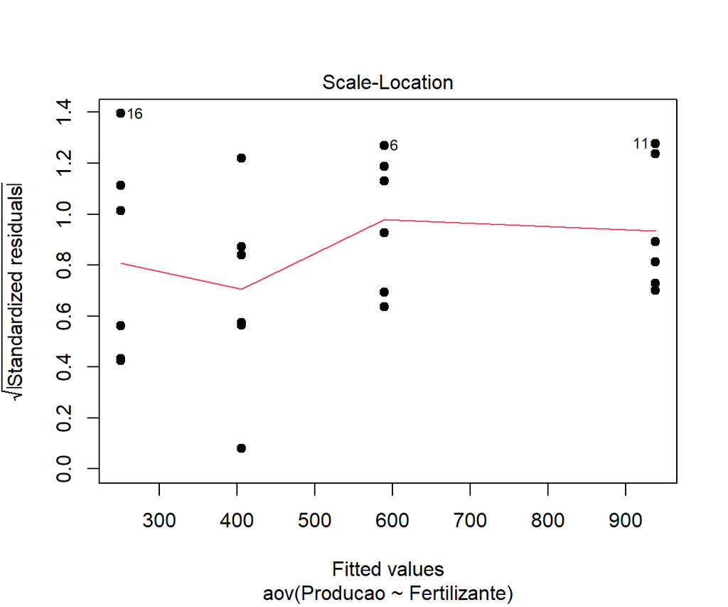

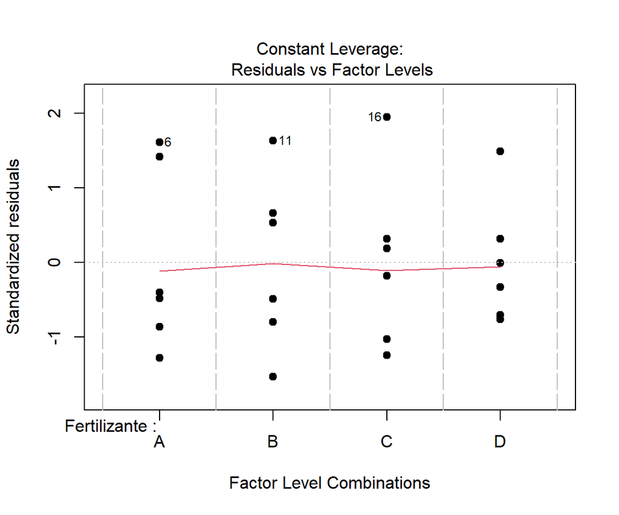

Visualmente não é possível observar algum padrão, logo temos que são dados aleatórios.

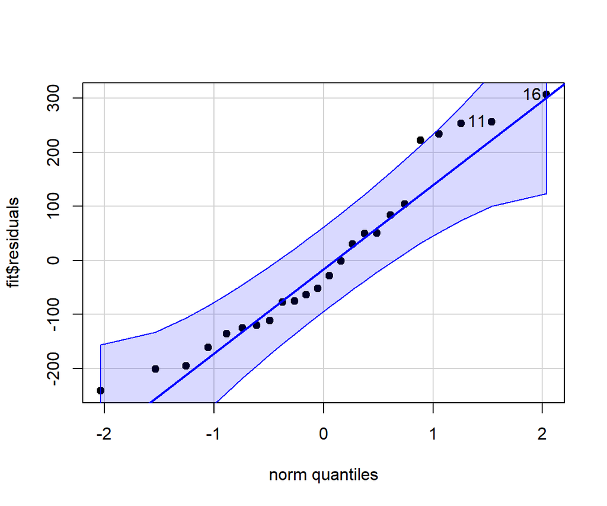

```
## [1] 16 11
```

A um ponto somente fora do envelope, para isso vamos utilizar o teste de Shapiro-Wilks.

```
##
##  Shapiro-Wilk normality test
##
## data:  fit$residuals
## W = 0.93551, p-value = 0.1295
```

Assumimos então que os resíduos são normais ao nível de significância de 5%.

Iremos utilizar o Teste de Bartlett para testar a Homoscedasticidade.

```
##
##  Bartlett test of homogeneity of variances
##
## data:  Producao by Fertilizante
## Bartlett's K-squared = 0.70949, df = 3, p-value = 0.871
```

Dessa forma assumimos que a variância é igual para os 4 tipos de fertilizantes em um nível de significância de 5%.

```
##   Tukey multiple comparisons of means
##     95% family-wise confidence level
##
## Fit: aov(formula = Producao ~ Fertilizante, data = base)
##
## $Fertilizante
##          diff        lwr       upr     p adj
## B-A  348.8333   70.09003  627.5766 0.0110653
## C-A -339.0000 -617.74330  -60.2567 0.0137652
## D-A -183.5000 -462.24330   95.2433 0.2836445
## C-B -687.8333 -966.57663 -409.0900 0.0000059
## D-B -532.3333 -811.07663 -253.5900 0.0001702
## D-C  155.5000 -123.24330  434.2433 0.4218483
```

Através do teste de tukey acima, a um nível de significância de 5% encontramos quê:

$A \neq B, A \neq C, B \neq C, B \neq D$

Como $B$ é diferente estatisticamente de todos e possui a maior media de Produção, podemos concluir que o Fertilizante B é o melhor dentre todos.

## Objetivo 2

### Quantidade de Praga em relação ao Fertilizante

```
##
##     0 1
##   A 4 2
##   B 3 3
##   C 4 2
##   D 4 2
```

```
##
##        0    1
##   A 0.17 0.08
##   B 0.12 0.12
##   C 0.17 0.08
##   D 0.17 0.08
```

### Proporção de Praga em relação ao Fertilizante

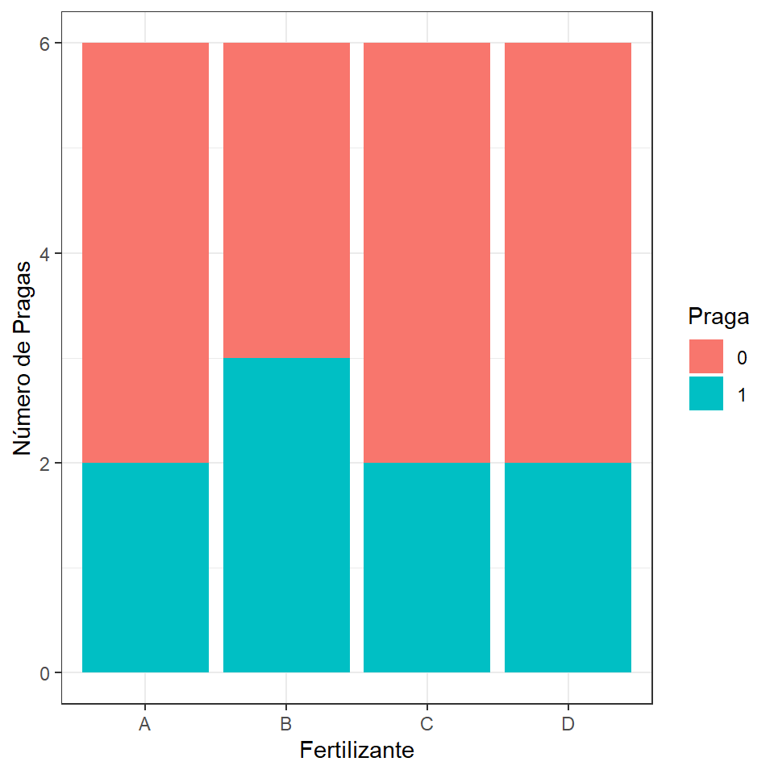

Visualmente não há diferença na presença de Praga nos diferentes tipos de Fertilizante.

### ANOVA

```
##
## Call:
## glm(formula = Praga ~ Fertilizante, family = binomial(), data = base)
##
## Deviance Residuals:
##     Min       1Q   Median       3Q      Max
## -1.1774  -0.9005  -0.9005   1.2536   1.4823
##
## Coefficients:
##                 Estimate Std. Error z value Pr(>|z|)
## (Intercept)   -6.931e-01  8.660e-01  -0.800    0.423
## FertilizanteB  6.931e-01  1.190e+00   0.582    0.560
## FertilizanteC  7.612e-16  1.225e+00   0.000    1.000
## FertilizanteD  8.158e-16  1.225e+00   0.000    1.000
##
## (Dispersion parameter for binomial family taken to be 1)
##
##     Null deviance: 31.755  on 23  degrees of freedom
## Residual deviance: 31.232  on 20  degrees of freedom
## AIC: 39.232
##
## Number of Fisher Scoring iterations: 4
```

Primeiramente foi feita uma regressão logística, onde em nenhum tratamento foi encontrada uma diferença significativa ao nível de significância de 5%.

```
## Analysis of Deviance Table
##
## Model: binomial, link: logit
##
## Response: Praga
##
## Terms added sequentially (first to last)
##
##
##              Df Deviance Resid. Df Resid. Dev Pr(>Chi)
## NULL                            23     31.755
## Fertilizante  3  0.52276        20     31.232   0.9139
```

Foi feita uma anova e constatamos que não há diferença estatística a um nível de significância de 5%, ou seja, nenhum Fertilizante causa menos Praga.

## Objetivo 3

### Produção em relação a Praga e aos tipos de Fertilizante

| Fertilizante | Praga | Mediana | Média | Mínimo | Máximo | Desvio Padrão | Variância |
| --- | --- | --- | --- | --- | --- | --- | --- |
| A | 0 | 669.0 | 658.75 | 454 | 843 | 197.47 | 38992.92 |
| A | 1 | 451.0 | 451.00 | 388 | 514 | 89.10 | 7938.00 |
| B | 0 | 861.0 | 866.67 | 697 | 1042 | 172.57 | 29780.33 |
| B | 1 | 1022.0 | 1010.00 | 813 | 1195 | 191.28 | 36589.00 |
| C | 0 | 155.5 | 166.50 | 55 | 300 | 114.51 | 13113.67 |
| C | 1 | 418.5 | 418.50 | 280 | 557 | 195.87 | 38364.50 |
| D | 0 | 405.0 | 436.25 | 295 | 640 | 151.24 | 22873.58 |
| D | 1 | 345.5 | 345.50 | 286 | 405 | 84.15 | 7080.50 |

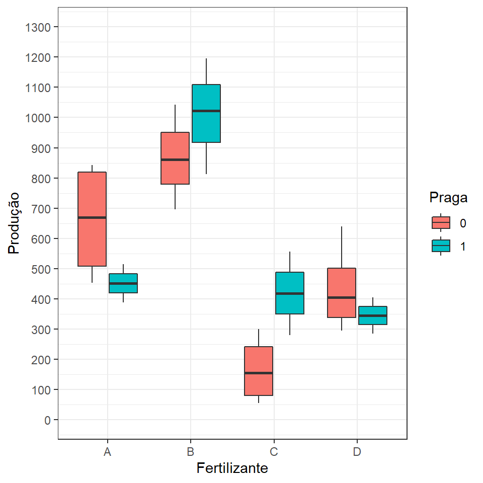

```
##                    Df  Sum Sq Mean Sq F value   Pr(>F)
## Fertilizante        3 1576427  525476  20.453 1.01e-05 ***
## Praga               1    4256    4256   0.166    0.689
## Fertilizante:Praga  3  179760   59920   2.332    0.113
## Residuals          16  411062   25691
## ---
## Signif. codes:  0 '***' 0.001 '**' 0.01 '*' 0.05 '.' 0.1 ' ' 1
```

Como o P Valor do Fertilizante:Praga não foi significativo, temos que a Praga não influencia a Produção de cada Fertilizante. Não iremos aprofundar pois será o tema da próxima aula.

## Conclusão

Concluímos que o melhor fertilizante é o B, pois tem a maior produção, também concluímos que nenhum fertilizante causa menos pragas do que os demais.